# IODS-project

Akseli Niemelä

# Introduction to Open Data Science - Course Project

# About the project

I am excited to start the course — and to start getting familiar with R  
As I read chapters 1 to 2 3 4 of *R for Health Data Science* in quick succession the amount of information was **overwhelming**. I hope I remember something for week 2.  
It was quite cumbersome to keep track of both the exercise set in RStudio and the webpage for the book. I ended up just following the book. Chapter 3 was definitely the hardest to get through, although probably its also the most important. I’m sure it will get easier with more exercises. Chapters 4 and 5 were the most fun, ggplot2 is very versatile.

`Speaking of versatile, Markdown is pretty nifty!`

[Link to my repository.](https://github.com/akselini/IODS-project)

#### Date giver

This code

1. gives the date.
2. greets you enthusiastically.

```r
date_1 <- "Today is"
date_2 <- format(Sys.Date(),format="%d of %B in %Y - happy %A!")
print(paste(date_1,date_2))
```

```
## [1] "Today is 10 of December in 2022 - happy Saturday!"
```

# Regression and model validation

*Describe the work you have done this week and summarize your learning.*

- Describe your work and results clearly.
- Assume the reader has an introductory course level understanding of writing and reading R code as well as statistical methods.
- Assume the reader has no previous knowledge of your data or the more advanced methods you are using.

```r
date()
```

```
## [1] "Sat Dec 10 21:33:18 2022"
```

### 1. Reading data

The data set to be analyzed has survey results from 166 students. It lists each student’s gender, age, attitude, exam points, and the extent of different learning strategies they utilized: deep approach, surface approach or strategic approach. Besides gender, the 7 variables are listed numerically.

```r
#read data
learning2014 <- read.table("data/learning2014.csv",sep=",",header=TRUE)
#check its structure
str(learning2014)
```

```
## 'data.frame':    166 obs. of  7 variables:
##  $ gender  : chr  "F" "M" "F" "M" ...
##  $ age     : int  53 55 49 53 49 38 50 37 37 42 ...
##  $ attitude: num  3.7 3.1 2.5 3.5 3.7 3.8 3.5 2.9 3.8 2.1 ...
##  $ deep    : num  3.58 2.92 3.5 3.5 3.67 ...
##  $ stra    : num  3.38 2.75 3.62 3.12 3.62 ...
##  $ surf    : num  2.58 3.17 2.25 2.25 2.83 ...
##  $ points  : int  25 12 24 10 22 21 21 31 24 26 ...
```

```r
#check its dimensions
dim(learning2014)
```

```
## [1] 166   7
```

It has 166 rows and 7 columns, the data is correct.

### 2. Graphical overview

As the data has been read correctly, next it will be investigated graphically.

```r
library(GGally)
```

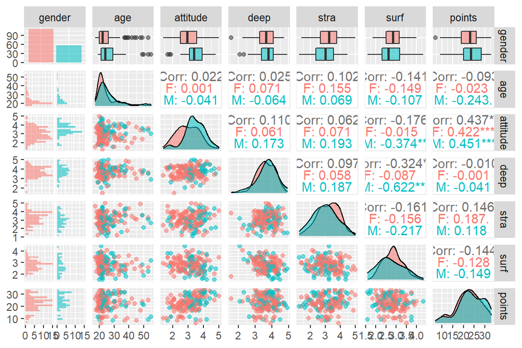

```r
library(ggplot2)
p <- ggpairs(learning2014, mapping = aes(col=gender,alpha=0.3), lower = list(combo = wrap("facethist", bins = 20)))
p
```

As can be seen, the data set has noticeably more females than males. The mean age for both groups is ~20, although the male distribution is more wide due to a lesser number of young students. The female attitude distribution is flat from 2.5-3.5, whereas male attitude is skewed higher. Both groups favor deep learning approaches, and less so strategic and surface level approaches - although females had a more narrow distribution than males. The exam point distribution for both groups is nearly equal, with males having a small peak at higher scores.  
Before looking at exam points, there’s two noticeable correlations. Males’ surface level learning and deep learning are significantly negatively correlated. A similar relationship is noticeable in males’ surface level learning and attitude. For the whole sample, strategic learning is negatively correlated with surface level learning.  
Finally, looking at the whole population, exam points are positively correlated with attitude and strategic learning (to a lesser extent) and negatively correlated with surface level learning.

### 3. Regression model

With the above mentioned three variables, we will make a regression model for exam points.

```r
m <- lm(points ~ attitude + stra + surf, data = learning2014)
summary(m)
```

```
##
## Call:
## lm(formula = points ~ attitude + stra + surf, data = learning2014)
##
## Residuals:
##      Min       1Q   Median       3Q      Max
## -17.1550  -3.4346   0.5156   3.6401  10.8952
##
## Coefficients:
##             Estimate Std. Error t value Pr(>|t|)
## (Intercept)  11.0171     3.6837   2.991  0.00322 **
## attitude      3.3952     0.5741   5.913 1.93e-08 ***
## stra          0.8531     0.5416   1.575  0.11716
## surf         -0.5861     0.8014  -0.731  0.46563
## ---
## Signif. codes:  0 '***' 0.001 '**' 0.01 '*' 0.05 '.' 0.1 ' ' 1
##
## Residual standard error: 5.296 on 162 degrees of freedom
## Multiple R-squared:  0.2074, Adjusted R-squared:  0.1927
## F-statistic: 14.13 on 3 and 162 DF,  p-value: 3.156e-08
```

As such the model is okay. The residual median is near 0 and on average a prediction may deviate by 5 points As stated previously attitude and strategic learning have a positive correlation whereas surface learning has negative.Looking at each contributing variable only attitude has a statistically significant relationship with exam points with a p-value of 1.93e-08. Thus we will remove the other variables from the model.

### 4. Corrected model

```r
m_corr <- lm(points ~ attitude, data = learning2014)
summary(m_corr)
```

```
##
## Call:
## lm(formula = points ~ attitude, data = learning2014)
##
## Residuals:
##      Min       1Q   Median       3Q      Max
## -16.9763  -3.2119   0.4339   4.1534  10.6645
##
## Coefficients:
##             Estimate Std. Error t value Pr(>|t|)
## (Intercept)  11.6372     1.8303   6.358 1.95e-09 ***
## attitude      3.5255     0.5674   6.214 4.12e-09 ***
## ---
## Signif. codes:  0 '***' 0.001 '**' 0.01 '*' 0.05 '.' 0.1 ' ' 1
##
## Residual standard error: 5.32 on 164 degrees of freedom
## Multiple R-squared:  0.1906, Adjusted R-squared:  0.1856
## F-statistic: 38.61 on 1 and 164 DF,  p-value: 4.119e-09
```

Now the p-value of attitude is 4.12e-09, and overall the model is better without the over fitting. The intercept is 11.6 so on average if a student scored 0 in the attitude survey their exam score would be this value. The slope for attitude is 3.53, so if attitude increases by one predicted exam points increase by this value. The multiple R-squared value of the model is 0.191, therefore, attitude can explain 19.1 % of variance in exam points.

### 5. Diagnostic plots

Finally, we will investigate the validity of the model with a few diagnostic plots.

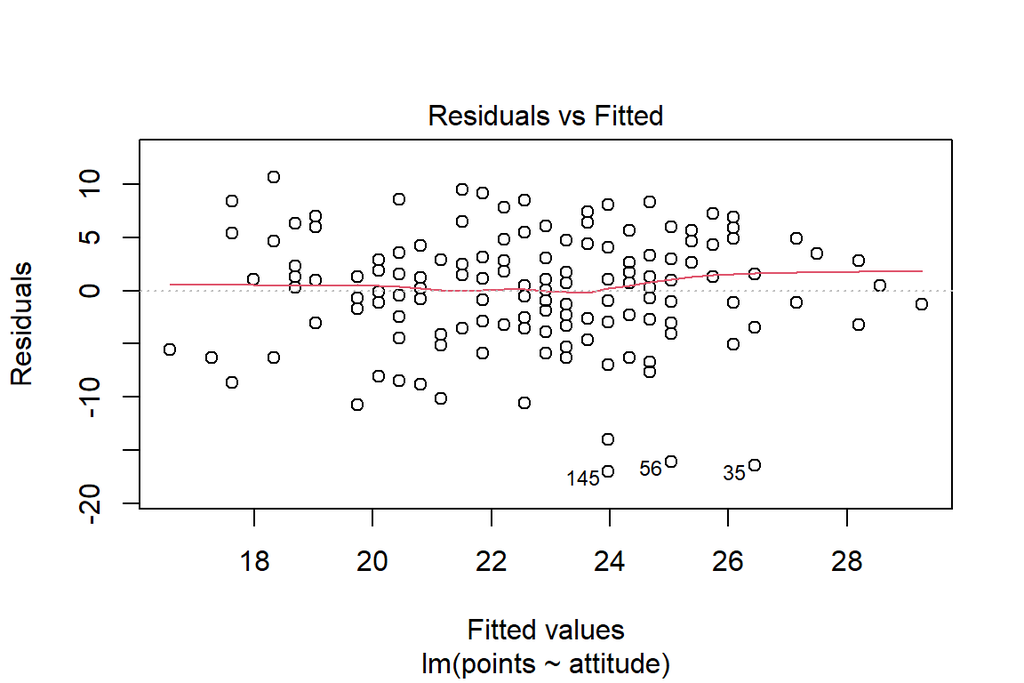

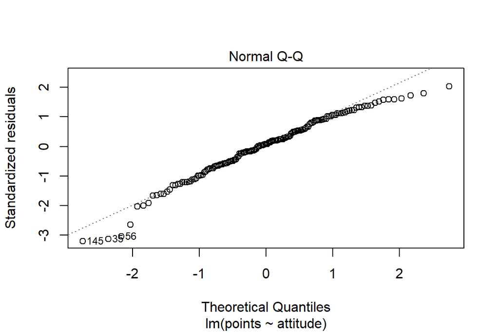

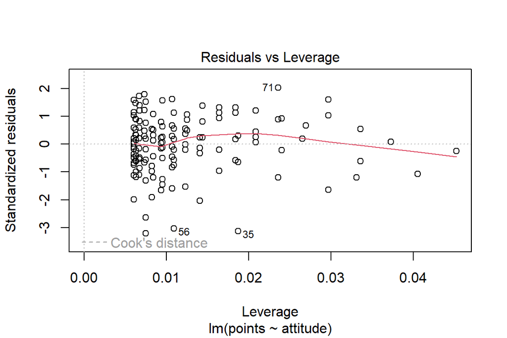

```r
#par(mfrow = c(2,2))
plot(m_corr,which=(c(1,2,5)))
```

The assumed linear relationship between attitude and exam points holds true, since the residuals vs fitted line is straight. Although the data points are generally well distributed on the line variance seems to be higher at lower exam scores. Subjects 145, 56 and 35 were identified as outliers.  
The Normal Q-Q plot shows that the residuals follow normal distribution well, although it is slightly skewed to higher values. The same outliers as before were noticed. Thus, the results of the statistical tests were valid.  
The residuals vs leverage plot tells us which data points were most influential for the model fitting. Outliers 56 and 35 are visible again, but instead of 145 71 was noticed. However, as no data points are outside Cook’s distance there are no outliers that significantly influenced our model. Thus, the model is robust enough that its fitting wouldn’t change a lot if some data points were removed.

# Logistic regression

*Describe the work you have done this week and summarize your learning.*

- Describe your work and results clearly.
- Assume the reader has an introductory course level understanding of writing and reading R code as well as statistical methods.
- Assume the reader has no previous knowledge of your data or the more advanced methods you are using.

```r
date()
```

```
## [1] "Sat Dec 10 21:33:28 2022"
```

### 2. Reading data

We’ll be investigating a combined data set on student alcohol consumption. The data was collected with surveys and school reports and it combines the math and portuguese subjects’ grades together.

```r
#read data
library(tidyverse)
alc <- read_csv("data/alc.csv",show_col_types=FALSE)
#check the involved variables
colnames(alc)
```

```
##  [1] "school"     "sex"        "age"        "address"    "famsize"
##  [6] "Pstatus"    "Medu"       "Fedu"       "Mjob"       "Fjob"
## [11] "reason"     "guardian"   "traveltime" "studytime"  "schoolsup"
## [16] "famsup"     "activities" "nursery"    "higher"     "internet"
## [21] "romantic"   "famrel"     "freetime"   "goout"      "Dalc"
## [26] "Walc"       "health"     "failures"   "paid"       "absences"
## [31] "G1"         "G2"         "G3"         "alc_use"    "high_use"
```

The collected data includes several background factors such as the attended school, sex, age, family size etc. We will be looking at how high alcohol consumption relates to the other factors. Alcohol use is classified high when the mean value of weekday and weekend alcohol use is 2 on a scale of 1-5.

### 3. Hypothesis creation

The four variables of interest relating to high alcohol use I’ve chosen are number of school absences, weekly study time, quality of family relationships and current health status.  
My hypotheses for these factors are the following: high alcohol use should -

1. positively correlate with absences
2. negatively correlate with weekly study time
3. negatively correlate with family relationship quality
4. negatively correlate with good health

### 4. Variable exploration

First let’s look at absences.

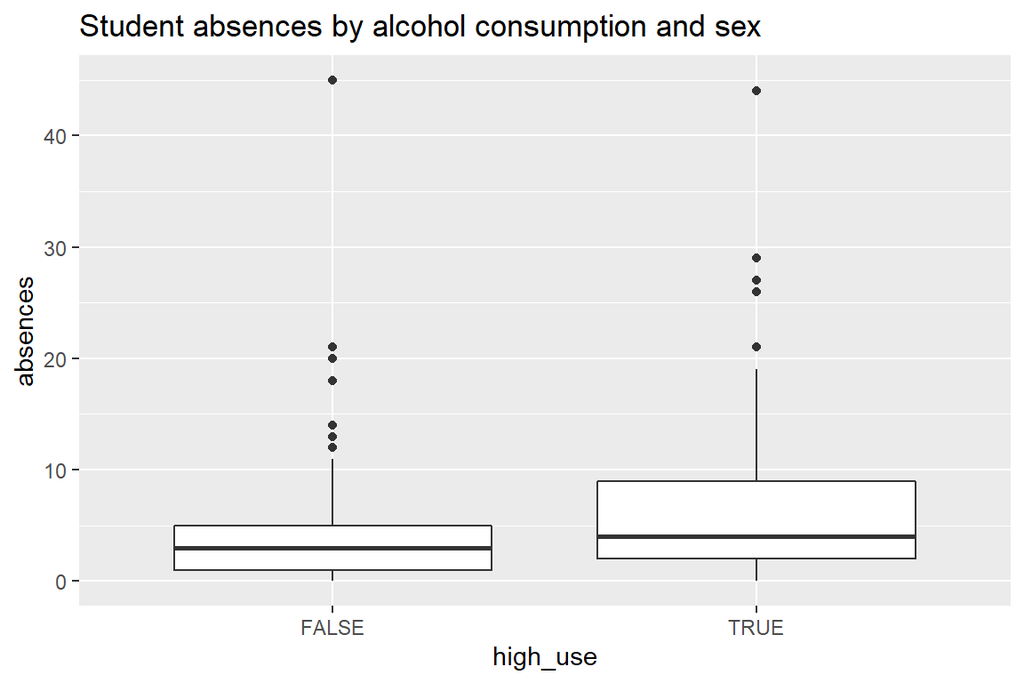

```r
library(dplyr); library(ggplot2)
#box plot
g1 <- ggplot(alc, aes(x = high_use, y = absences))
g1 + geom_boxplot() + ylab("absences") + ggtitle("Student absences by alcohol consumption and sex")
```

The first hypothesis seems to hold true, next weekly study time.

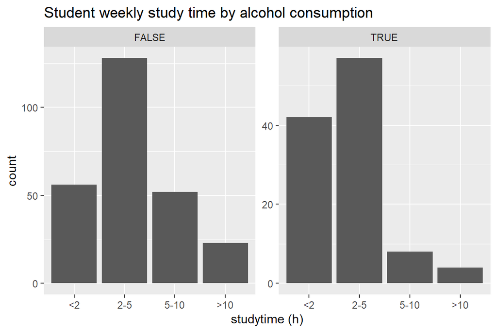

```r
#bar plot
g2 <- ggplot(data = alc,aes(x=factor(studytime)))
g2 + geom_bar() + facet_wrap("high_use", scales = "free_y")+ xlab("studytime (h)")+scale_x_discrete(labels=c("1" = "<2", "2" = "2-5","3" = "5-10","4" = ">10"))  + ggtitle("Student weekly study time by alcohol consumption")
```

Looking at the distribution, it is clear students with high alcohol use had less study time during the week as expected. Next, family relationship quality

```r
#cross tabulation
alc %>% group_by(high_use) %>% summarise(count = n(), mean_family_relationship_quality=mean(famrel))
```

```
## # A tibble: 2 × 3
##   high_use count mean_family_relationship_quality
##   <lgl>    <int>                            <dbl>
## 1 FALSE      259                             4.01
## 2 TRUE       111                             3.77
```

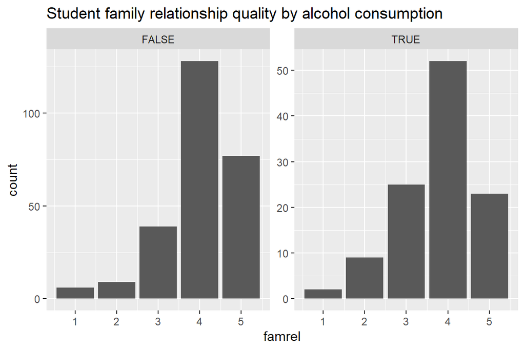

```r
#bar plot
g3 <- ggplot(data = alc,aes(x=famrel))
g3 + geom_bar() + facet_wrap("high_use",scales="free_y") + ggtitle("Student family relationship quality by alcohol consumption")
```

There is a small difference in the mean value as per the third hypothesis. Additionally, by looking at the distribution we can identify that for low alcohol use students the distribution is skewed to the left, whereas for high alcohol use students it is more normally distributed. Finally, health is looked at.

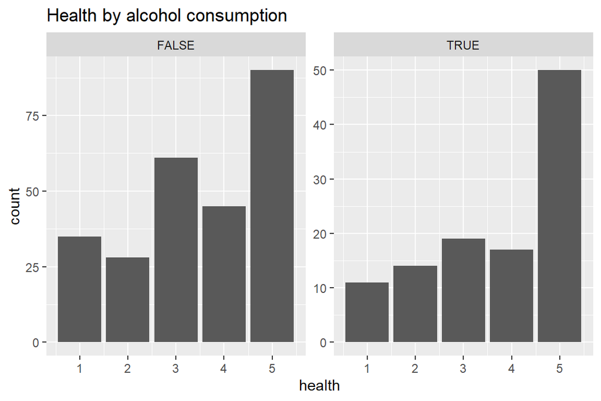

```r
#bar plot
g4 <- ggplot(data = alc,aes(x=health))
g4 + geom_bar() + facet_wrap("high_use",scales="free_y") + ggtitle("Health by alcohol consumption")
```

Interestingly, here the hypothesis was proven wrong. High alcohol use students reported their health to be in the best quality far more than low alcohol use students, who had a more variable distribution.  
Overall, 3/4 hypotheses proved correct. Why in this population the last hypothesis on alcohol consumption and health was incorrect could be due to higher outgoingness in the high use group, which would result in more physical activity. It could also be explained by self-report bias.

### 5. Logistic regression model

Using these variables, we will create a logistic regression model for alcohol consumption.

```r
m <- glm(high_use ~ absences + studytime + famrel + health, data = alc, family = "binomial")
#summary of the model
summary(m)
```

```
##
## Call:
## glm(formula = high_use ~ absences + studytime + famrel + health,
##     family = "binomial", data = alc)
##
## Deviance Residuals:
##     Min       1Q   Median       3Q      Max
## -2.2118  -0.8257  -0.6367   1.1877   2.1088
##
## Coefficients:
##             Estimate Std. Error z value Pr(>|z|)
## (Intercept)  0.46728    0.66691   0.701 0.483510
## absences     0.07667    0.02254   3.402 0.000670 ***
## studytime   -0.54552    0.15722  -3.470 0.000521 ***
## famrel      -0.27725    0.12933  -2.144 0.032045 *
## health       0.12762    0.08747   1.459 0.144565
## ---
## Signif. codes:  0 '***' 0.001 '**' 0.01 '*' 0.05 '.' 0.1 ' ' 1
##
## (Dispersion parameter for binomial family taken to be 1)
##
##     Null deviance: 452.04  on 369  degrees of freedom
## Residual deviance: 413.70  on 365  degrees of freedom
## AIC: 423.7
##
## Number of Fisher Scoring iterations: 4
```

```r
#get odds ratios
OR <- coef(m) %>% exp
#get confidence intervals
CI <- confint(m) %>% exp
#print both
cbind(OR, CI)
```

```
##                    OR     2.5 %    97.5 %
## (Intercept) 1.5956550 0.4296568 5.9289512
## absences    1.0796821 1.0351723 1.1312382
## studytime   0.5795420 0.4216137 0.7820553
## famrel      0.7578629 0.5871334 0.9765758
## health      1.1361197 0.9591423 1.3526070
```

### 6. Predictive power

We’ll only take the significant variables and see how this model performs.

```r
#make new model
new_m <- glm(high_use ~ absences + studytime + famrel, data = alc, family = "binomial")
#predict for each student whether they are high_use or not based on the variables
alc <- mutate(alc, probability = predict(new_m, type = "response"))
alc <- mutate(alc, prediction = probability > 0.5)

#cross tabulation
table(high_use = alc$high_use, prediction = alc$prediction) %>% prop.table()
```

```
##         prediction
## high_use      FALSE       TRUE
##    FALSE 0.65945946 0.04054054
##    TRUE  0.25405405 0.04594595
```

```r
#optionally calculate training error with loss function
loss_func <- function(class, prob) {
  n_wrong <- abs(class - prob) > 0.5
  mean(n_wrong)
}
loss_func(class = alc$high_use, prob = alc$probability)
```

```
## [1] 0.2945946
```

```r
#creating simple guessing strategy, randomly assign a number for each student within the range of student number
random_num <- sample(1:nrow(alc),nrow(alc))
alc <- mutate(alc, rand = random_num)
#count the number of high use students
num_high_use <- sum(alc$high_use)
#if the random index is below the number of high use students predict them as a high use student
alc <- mutate(alc, naive_prediction = rand < num_high_use)
#this results in random guessing, but at least the proportion of high use students should be similar
print("True number of high use students:")
```

```
## [1] "True number of high use students:"
```

```r
sum(alc$high_use)
```

```
## [1] 111
```

```r
print("Randomly assigned number of high use students:")
```

```
## [1] "Randomly assigned number of high use students:"
```

```r
sum(alc$naive_prediction)
```

```
## [1] 110
```

```r
#finally, test its function with cross tabulation
table(high_use = alc$high_use, prediction = alc$naive_prediction) %>% prop.table()
```

```
##         prediction
## high_use      FALSE       TRUE
##    FALSE 0.48378378 0.21621622
##    TRUE  0.21891892 0.08108108
```

### 7. 10-fold cross validation

Next, we will check its predictive power using a 10-fold cross-validation.

```r
library(boot)
cv10 <- cv.glm(data = alc, cost = loss_func, glmfit = new_m, K = 10)
cv10$delta[1]
```

```
## [1] 0.3027027
```

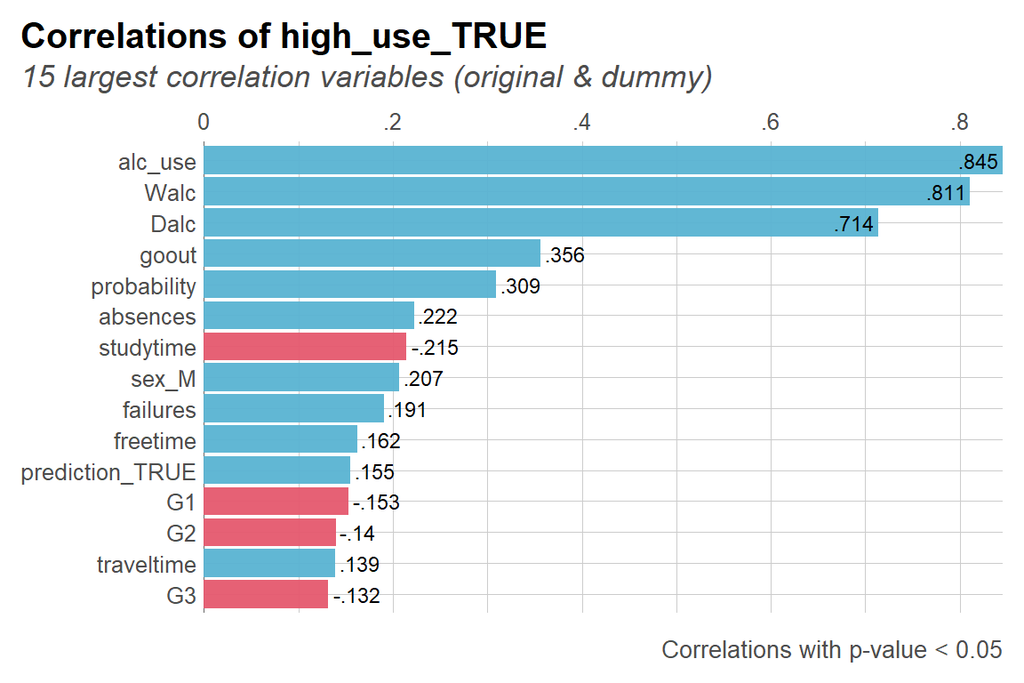

```r
library(lares)
#find highest correlations with a quick and dirty method found via google: https://statsandr.com/blog/correlogram-in-r-how-to-highlight-the-most-correlated-variables-in-a-dataset/
corr_var(alc,high_use,max_pvalue=0.05,top=15)
```

```r
better_m <- glm(high_use ~ goout + absences + studytime + sex, data = alc, family= "binomial")
#check significance, if variables not significant iterate ^
summary(better_m)
```

```
##
## Call:
## glm(formula = high_use ~ goout + absences + studytime + sex,
##     family = "binomial", data = alc)
##
## Deviance Residuals:
##     Min       1Q   Median       3Q      Max
## -1.9330  -0.7896  -0.4956   0.7414   2.6125
##
## Coefficients:
##             Estimate Std. Error z value Pr(>|z|)
## (Intercept) -3.19268    0.59956  -5.325 1.01e-07 ***
## goout        0.72483    0.12086   5.997 2.01e-09 ***
## absences     0.07853    0.02274   3.454 0.000553 ***
## studytime   -0.43466    0.17177  -2.530 0.011393 *
## sexM         0.83999    0.27053   3.105 0.001903 **
## ---
## Signif. codes:  0 '***' 0.001 '**' 0.01 '*' 0.05 '.' 0.1 ' ' 1
##
## (Dispersion parameter for binomial family taken to be 1)
##
##     Null deviance: 452.04  on 369  degrees of freedom
## Residual deviance: 367.31  on 365  degrees of freedom
## AIC: 377.31
##
## Number of Fisher Scoring iterations: 4
```

```r
better_cv10 <- cv.glm(data = alc, cost = loss_func, glmfit = better_m, K = 10)
better_cv10$delta[1]
```

```
## [1] 0.2054054
```

In the end, to keep all variables statistically significant, best ones noted were going out with friends, absences, study time and sex. This resulted in a model with an error of ~0.21.

### 8. Comparing different logistic models

Let’s start with 10 best predictors collected from previous graph and gradually lessen them.

```r
model_errors <- numeric(0)
model_errors[10] <-cv.glm(data = alc, cost = loss_func, glmfit = glm(high_use ~ goout + absences + studytime + sex + failures + freetime + G1 + G2 + traveltime + G3, data = alc, family= "binomial"), K = 10)$delta[1]
model_errors[9] <-cv.glm(data = alc, cost = loss_func, glmfit = glm(high_use ~ goout + absences + studytime + sex + failures + freetime + G1 + G2 + traveltime, data = alc, family= "binomial"), K = 10)$delta[1]
model_errors[8] <-cv.glm(data = alc, cost = loss_func, glmfit = glm(high_use ~ goout + absences + studytime + sex + failures + freetime + G1 + G2, data = alc, family= "binomial"), K = 10)$delta[1]
model_errors[7] <-cv.glm(data = alc, cost = loss_func, glmfit = glm(high_use ~ goout + absences + studytime + sex + failures + freetime + G1, data = alc, family= "binomial"), K = 10)$delta[1]
model_errors[6] <-cv.glm(data = alc, cost = loss_func, glmfit = glm(high_use ~ goout + absences + studytime + sex + failures + freetime, data = alc, family= "binomial"), K = 10)$delta[1]
model_errors[5] <-cv.glm(data = alc, cost = loss_func, glmfit = glm(high_use ~ goout + absences + studytime + sex + failures, data = alc, family= "binomial"), K = 10)$delta[1]
model_errors[4] <-cv.glm(data = alc, cost = loss_func, glmfit = glm(high_use ~ goout + absences + studytime + sex, data = alc, family= "binomial"), K = 10)$delta[1]
model_errors[3] <-cv.glm(data = alc, cost = loss_func, glmfit = glm(high_use ~ goout + absences + studytime, data = alc, family= "binomial"), K = 10)$delta[1]
model_errors[2] <-cv.glm(data = alc, cost = loss_func, glmfit = glm(high_use ~ goout + absences, data = alc, family= "binomial"), K = 10)$delta[1]
model_errors[1] <-cv.glm(data = alc, cost = loss_func, glmfit = glm(high_use ~ goout, data = alc, family= "binomial"), K = 10)$delta[1]

predictor_num <- c(1:10)
df <- data.frame(model_errors,predictor_num)
colnames(df)
```

```
## [1] "model_errors"  "predictor_num"
```

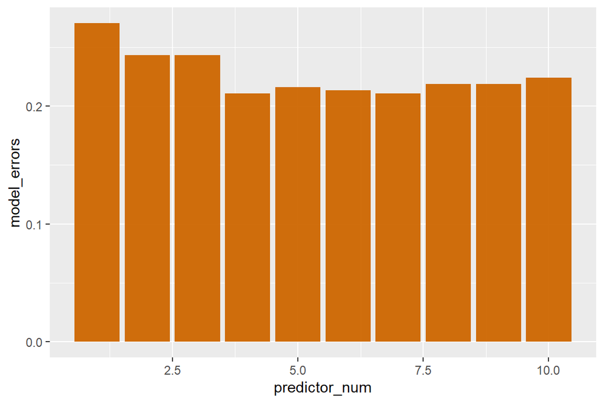

```r
g5 <- ggplot(data = df,aes(x=predictor_num,y=model_errors))
g5 + geom_bar(stat = "identity")
```

After the first 4 predictors the error doesn’t keep decreasing and instead flatlines, sometimes even increasing. This is probably a case of overfitting.

# Clustering and classification

*Describe the work you have done this week and summarize your learning.*

- Describe your work and results clearly.
- Assume the reader has an introductory course level understanding of writing and reading R code as well as statistical methods.
- Assume the reader has no previous knowledge of your data or the more advanced methods you are using.

```r
date()
```

```
## [1] "Sat Dec 10 21:33:41 2022"
```

### 2.Loading data

First, we’ll load in the data.

```r
library(tidyverse)
library(MASS)
#load data
data("Boston")
#explore it
glimpse(Boston)
```

```
## Rows: 506
## Columns: 14
## $ crim    <dbl> 0.00632, 0.02731, 0.02729, 0.03237, 0.06905, 0.02985, 0.08829,…
## $ zn      <dbl> 18.0, 0.0, 0.0, 0.0, 0.0, 0.0, 12.5, 12.5, 12.5, 12.5, 12.5, 1…
## $ indus   <dbl> 2.31, 7.07, 7.07, 2.18, 2.18, 2.18, 7.87, 7.87, 7.87, 7.87, 7.…
## $ chas    <int> 0, 0, 0, 0, 0, 0, 0, 0, 0, 0, 0, 0, 0, 0, 0, 0, 0, 0, 0, 0, 0,…
## $ nox     <dbl> 0.538, 0.469, 0.469, 0.458, 0.458, 0.458, 0.524, 0.524, 0.524,…
## $ rm      <dbl> 6.575, 6.421, 7.185, 6.998, 7.147, 6.430, 6.012, 6.172, 5.631,…
## $ age     <dbl> 65.2, 78.9, 61.1, 45.8, 54.2, 58.7, 66.6, 96.1, 100.0, 85.9, 9…
## $ dis     <dbl> 4.0900, 4.9671, 4.9671, 6.0622, 6.0622, 6.0622, 5.5605, 5.9505…
## $ rad     <int> 1, 2, 2, 3, 3, 3, 5, 5, 5, 5, 5, 5, 5, 4, 4, 4, 4, 4, 4, 4, 4,…
## $ tax     <dbl> 296, 242, 242, 222, 222, 222, 311, 311, 311, 311, 311, 311, 31…
## $ ptratio <dbl> 15.3, 17.8, 17.8, 18.7, 18.7, 18.7, 15.2, 15.2, 15.2, 15.2, 15…
## $ black   <dbl> 396.90, 396.90, 392.83, 394.63, 396.90, 394.12, 395.60, 396.90…
## $ lstat   <dbl> 4.98, 9.14, 4.03, 2.94, 5.33, 5.21, 12.43, 19.15, 29.93, 17.10…
## $ medv    <dbl> 24.0, 21.6, 34.7, 33.4, 36.2, 28.7, 22.9, 27.1, 16.5, 18.9, 15…
```

The Boston data set included in the MASS library lists housing values in the suburbs of Boston, as well as relevant census factors such as crime rate, proportion of land zoned for lots, nitrogen oxide concentrations and pupil-teacher ratio. There’s 506 observations with 14 variables.

### 3. Graphical overview

Let’s look at the data more carefully.

```r
library(corrplot)
#get mean data on variables
summary(Boston)
```

```
##       crim                zn             indus            chas
##  Min.   : 0.00632   Min.   :  0.00   Min.   : 0.46   Min.   :0.00000
##  1st Qu.: 0.08205   1st Qu.:  0.00   1st Qu.: 5.19   1st Qu.:0.00000
##  Median : 0.25651   Median :  0.00   Median : 9.69   Median :0.00000
##  Mean   : 3.61352   Mean   : 11.36   Mean   :11.14   Mean   :0.06917
##  3rd Qu.: 3.67708   3rd Qu.: 12.50   3rd Qu.:18.10   3rd Qu.:0.00000
##  Max.   :88.97620   Max.   :100.00   Max.   :27.74   Max.   :1.00000
##       nox               rm             age              dis
##  Min.   :0.3850   Min.   :3.561   Min.   :  2.90   Min.   : 1.130
##  1st Qu.:0.4490   1st Qu.:5.886   1st Qu.: 45.02   1st Qu.: 2.100
##  Median :0.5380   Median :6.208   Median : 77.50   Median : 3.207
##  Mean   :0.5547   Mean   :6.285   Mean   : 68.57   Mean   : 3.795
##  3rd Qu.:0.6240   3rd Qu.:6.623   3rd Qu.: 94.08   3rd Qu.: 5.188
##  Max.   :0.8710   Max.   :8.780   Max.   :100.00   Max.   :12.127
##       rad              tax           ptratio          black
##  Min.   : 1.000   Min.   :187.0   Min.   :12.60   Min.   :  0.32
##  1st Qu.: 4.000   1st Qu.:279.0   1st Qu.:17.40   1st Qu.:375.38
##  Median : 5.000   Median :330.0   Median :19.05   Median :391.44
##  Mean   : 9.549   Mean   :408.2   Mean   :18.46   Mean   :356.67
##  3rd Qu.:24.000   3rd Qu.:666.0   3rd Qu.:20.20   3rd Qu.:396.23
##  Max.   :24.000   Max.   :711.0   Max.   :22.00   Max.   :396.90
##      lstat            medv
##  Min.   : 1.73   Min.   : 5.00
##  1st Qu.: 6.95   1st Qu.:17.02
##  Median :11.36   Median :21.20
##  Mean   :12.65   Mean   :22.53
##  3rd Qu.:16.95   3rd Qu.:25.00
##  Max.   :37.97   Max.   :50.00
```

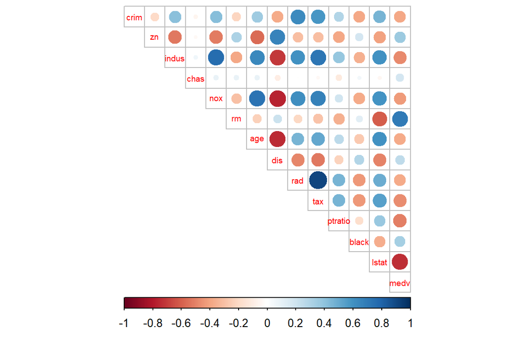

```r
#create correlation matrix
cor_matrix <- cor(Boston) %>% round(digits = 2)
#draw the correlation plot
corrplot(cor_matrix, method="circle",type="upper",cl.pos = "b",tl.pos = "d",tl.cex=0.6)
```

From the summaries we can see that the mean per capita crime rate is 3.6, but as the median is 0.25 it seems that the distribution is skewed due to some high crime rate towns. Similarly, given that the maximum median value of owner occupied houses is 10-fold larger than the minimum, there’s a large income division between towns.  
Looking at the plot, the median value of owner occupied houses is negatively correlated with lower status of the population and positively with average number of rooms per dwelling, which makes sense. Crime on the other hand has the largest correlation with the index of accessibility to radial highways, which also makes sense given radial highways link to urban centers which have a high population density. There are other interesting correlations, but I’ll highlight one last one between nitrogen oxides concentration and proportion of non-retail businesses, whose correlation profiles almost identical.

### 4. Data set standardization

Now, we’ll scale the data.

```r
#scale variables and show their summary
boston_scaled <- as.data.frame(scale(Boston))
summary(boston_scaled)
```

```
##       crim                 zn               indus              chas
##  Min.   :-0.419367   Min.   :-0.48724   Min.   :-1.5563   Min.   :-0.2723
##  1st Qu.:-0.410563   1st Qu.:-0.48724   1st Qu.:-0.8668   1st Qu.:-0.2723
##  Median :-0.390280   Median :-0.48724   Median :-0.2109   Median :-0.2723
##  Mean   : 0.000000   Mean   : 0.00000   Mean   : 0.0000   Mean   : 0.0000
##  3rd Qu.: 0.007389   3rd Qu.: 0.04872   3rd Qu.: 1.0150   3rd Qu.:-0.2723
##  Max.   : 9.924110   Max.   : 3.80047   Max.   : 2.4202   Max.   : 3.6648
##       nox                rm               age               dis
##  Min.   :-1.4644   Min.   :-3.8764   Min.   :-2.3331   Min.   :-1.2658
##  1st Qu.:-0.9121   1st Qu.:-0.5681   1st Qu.:-0.8366   1st Qu.:-0.8049
##  Median :-0.1441   Median :-0.1084   Median : 0.3171   Median :-0.2790
##  Mean   : 0.0000   Mean   : 0.0000   Mean   : 0.0000   Mean   : 0.0000
##  3rd Qu.: 0.5981   3rd Qu.: 0.4823   3rd Qu.: 0.9059   3rd Qu.: 0.6617
##  Max.   : 2.7296   Max.   : 3.5515   Max.   : 1.1164   Max.   : 3.9566
##       rad               tax             ptratio            black
##  Min.   :-0.9819   Min.   :-1.3127   Min.   :-2.7047   Min.   :-3.9033
##  1st Qu.:-0.6373   1st Qu.:-0.7668   1st Qu.:-0.4876   1st Qu.: 0.2049
##  Median :-0.5225   Median :-0.4642   Median : 0.2746   Median : 0.3808
##  Mean   : 0.0000   Mean   : 0.0000   Mean   : 0.0000   Mean   : 0.0000
##  3rd Qu.: 1.6596   3rd Qu.: 1.5294   3rd Qu.: 0.8058   3rd Qu.: 0.4332
##  Max.   : 1.6596   Max.   : 1.7964   Max.   : 1.6372   Max.   : 0.4406
##      lstat              medv
##  Min.   :-1.5296   Min.   :-1.9063
##  1st Qu.:-0.7986   1st Qu.:-0.5989
##  Median :-0.1811   Median :-0.1449
##  Mean   : 0.0000   Mean   : 0.0000
##  3rd Qu.: 0.6024   3rd Qu.: 0.2683
##  Max.   : 3.5453   Max.   : 2.9865
```

```r
#create categorical variable crime to replace crim
boston_scaled$crim <- as.numeric(boston_scaled$crim)
bins <- quantile(boston_scaled$crim)
crime <- cut(boston_scaled$crim, breaks = bins, include.lowest = TRUE,labels = c("low","med_low","med_high","high"))
boston_scaled <- dplyr::select(boston_scaled, -crim)
boston_scaled <- data.frame(boston_scaled, crime)

#create train and test set with 0.8:0.2 proportion
n <- nrow(boston_scaled)
ind <- sample(n,  size = n * 0.8)
train <- boston_scaled[ind,]
test <- boston_scaled[-ind,]
```

Now all of the scaled variables have a mean value of 0.

### 5. Linear discriminant analysis fitting

Next, we’ll create a LDA model for predicting the categorical crime rate.

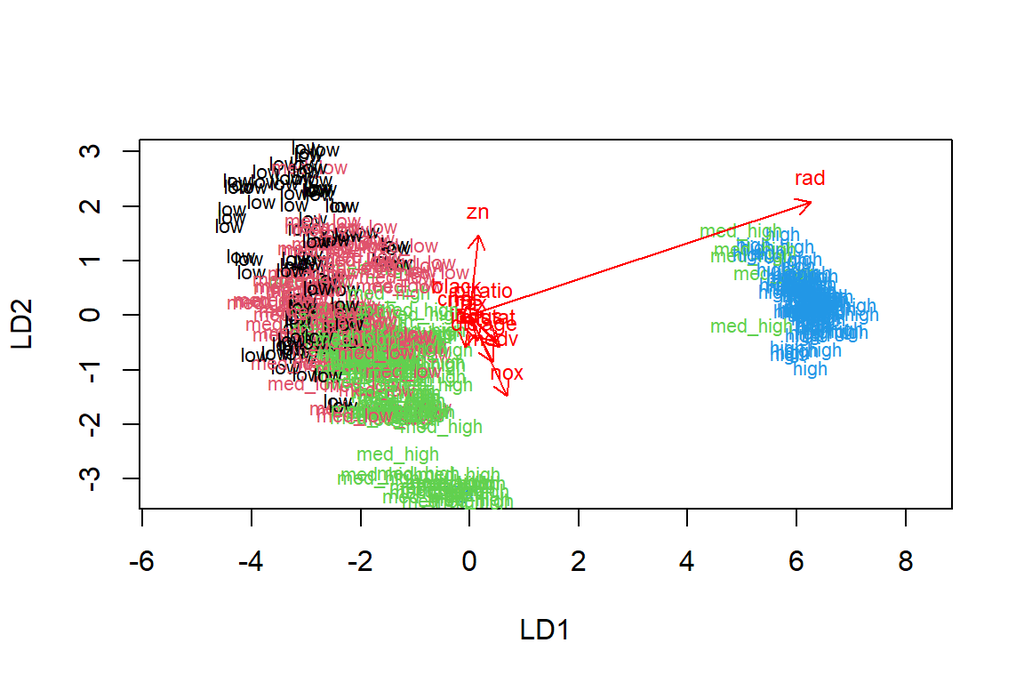

```r
#creating the model
lda.fit <- lda(crime ~ ., data = train)
#arrows for visualization
lda.arrows <- function(x, myscale = 1, arrow_heads = 0.1, color = "red", tex = 0.75, choices = c(1,2)){
  heads <- coef(x)
  arrows(x0 = 0, y0 = 0,
         x1 = myscale * heads[,choices[1]],
         y1 = myscale * heads[,choices[2]], col=color, length = arrow_heads)
  text(myscale * heads[,choices], labels = row.names(heads),
       cex = tex, col=color, pos=3)
}
#turning classes numeric for visualization
classes <- factor(train$crime) %>% unclass() %>% as.numeric()
plot(lda.fit,dimen=2,col = classes,pch=classes)
lda.arrows(lda.fit, myscale = 2)
```

LDA was able to separate the high crime towns very well from the other towns using index of accessibility to radial highways. Similarly there is a clear gradient from low to med_high towns caused by nitrogen oxides concentration and proportion of residential land zoned for lots, in other words, areas like suburbs have less crime whereas urban areas have more. (Sidenote: I couldn’t get pch to work in plot())

### 6. Prediction and evaluation

Let’s use the trained model to predict the values of our test set.

```r
#save the crime data from the test set and remove it
correct_classes <- test$crime
test <- dplyr::select(test, -crime)

#predict with the created model
lda.pred <- predict(lda.fit, newdata = test)

#perform cross tabulation
table(correct = correct_classes, predicted = lda.pred$class)
```

```
##           predicted
## correct    low med_low med_high high
##   low       12      10        4    0
##   med_low    2      16        9    0
##   med_high   0       5       16    1
##   high       0       0        0   27
```

The model predicted the majority of the test set correctly. The false predictions are definitely higher at the lower crime rate towns as they aren’t separated by the index of accessibility to radial highways.

### 7. Clustering

Finally, we’ll perform k-means clustering.

```r
#reload and scale data set
data(Boston)
boston_scaled <- scale(Boston)

#create euclidean distance matrix and view its summary
dist_eu <- dist(boston_scaled)
summary(dist_eu)
```

```
##    Min. 1st Qu.  Median    Mean 3rd Qu.    Max.
##  0.1343  3.4625  4.8241  4.9111  6.1863 14.3970
```

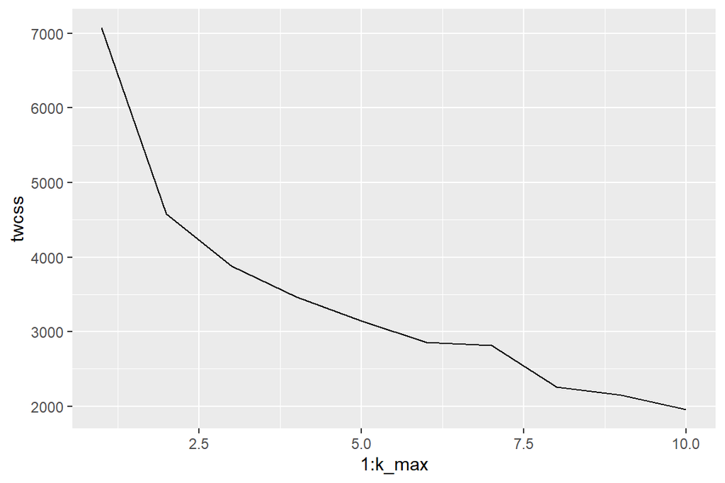

```r
#find optimal number of clusters
set.seed(123)
k_max <- 10
twcss <- sapply(1:k_max, function(k){kmeans(boston_scaled, k)$tot.withinss})
#visualize
qplot(x = 1:k_max, y = twcss, geom = 'line')
```

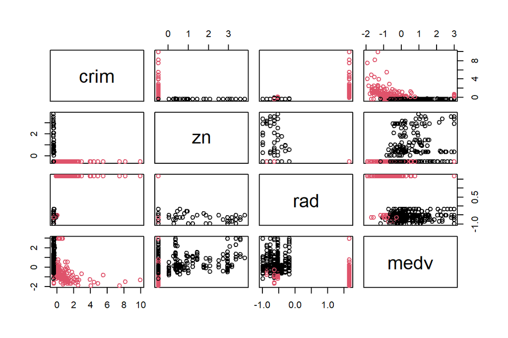

```r
#2 clusters seems to be optimal

#perform k-means clustering to create 2 clusters
km <- kmeans(boston_scaled, centers = 2)
pairs(boston_scaled[,c(1,2,9,14)], col = km$cluster)
```

Two clusters seems to be optimal based on the WCSS plot, and looking at the pairs plot for some of the variables of interest indeed shows a clear separation of two populations. For example, when crime is low, the median values can be high, whereas all the high crime towns have low median values. Next let’s try LDA for the clusters

```r
#I removed chas as for some reason lda() throws an error when chas is included stating it is constant, even though the summary shows it isn't
boston_scaled <- as.data.frame(boston_scaled)
summary(boston_scaled$chas)
```

```
##    Min. 1st Qu.  Median    Mean 3rd Qu.    Max.
## -0.2723 -0.2723 -0.2723  0.0000 -0.2723  3.6648
```

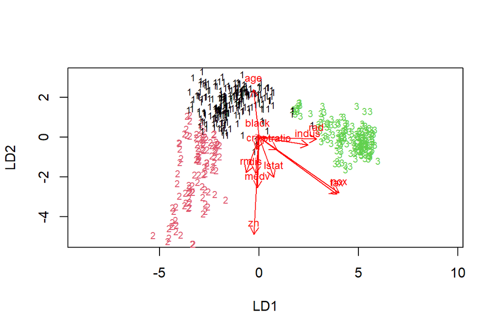

```r
boston_scaled <- dplyr::select(boston_scaled, -chas)

#create new model with 3 clusters
km_new <- kmeans(boston_scaled, centers = 3)

#add the cluster classification as a column
boston_scaled <- mutate(boston_scaled,clu = km_new$cluster)

#perform lda on cluster
lda.fit <- lda(clu ~ ., data = boston_scaled)

#arrows for visualization
lda.arrows <- function(x, myscale = 1, arrow_heads = 0.1, color = "red", tex = 0.75, choices = c(1,2)){
  heads <- coef(x)
  arrows(x0 = 0, y0 = 0,
         x1 = myscale * heads[,choices[1]],
         y1 = myscale * heads[,choices[2]], col=color, length = arrow_heads)
  text(myscale * heads[,choices], labels = row.names(heads),
       cex = tex, col=color, pos=3)
}
#use for visualization
classes <- factor(boston_scaled$clu) %>% unclass() %>% as.numeric()
plot(lda.fit,dimen=2,col = classes,pch=classes)
lda.arrows(lda.fit, myscale = 4)
```

Now several predictors such as nitrogen oxides concentration, taxes, proportion of industry, access to radial highways separate group 3, and age and proportion of residential land separate groups 1 and 2.

# Dimensionality reduction techniques

*Describe the work you have done this week and summarize your learning.*

- Describe your work and results clearly.
- Assume the reader has an introductory course level understanding of writing and reading R code as well as statistical methods.
- Assume the reader has no previous knowledge of your data or the more advanced methods you are using.

```r
date()
```

```
## [1] "Sat Dec 10 21:33:46 2022"
```

### 1. Graphical overview

Let’s load in the data and take a look at it.

```r
#read data
library(tidyverse)
human <- read.csv("data/human2.csv",row.names=1)
glimpse(human)
```

```
## Rows: 155
## Columns: 8
## $ Edu2.FM   <dbl> 1.0072389, 0.9968288, 0.9834369, 0.9886128, 0.9690608, 0.992…
## $ Labo.FM   <dbl> 0.8908297, 0.8189415, 0.8251001, 0.8840361, 0.8286119, 0.807…
## $ Life.Exp  <dbl> 81.6, 82.4, 83.0, 80.2, 81.6, 80.9, 80.9, 79.1, 82.0, 81.8, …
## $ Edu.Exp   <dbl> 17.5, 20.2, 15.8, 18.7, 17.9, 16.5, 18.6, 16.5, 15.9, 19.2, …
## $ GNI       <int> 64992, 42261, 56431, 44025, 45435, 43919, 39568, 52947, 4215…
## $ Mat.Mor   <int> 4, 6, 6, 5, 6, 7, 9, 28, 11, 8, 6, 4, 8, 4, 27, 2, 11, 6, 6,…
## $ Ado.Birth <dbl> 7.8, 12.1, 1.9, 5.1, 6.2, 3.8, 8.2, 31.0, 14.5, 25.3, 6.0, 6…
## $ Parli.F   <dbl> 39.6, 30.5, 28.5, 38.0, 36.9, 36.9, 19.9, 19.4, 28.2, 31.4, …
```

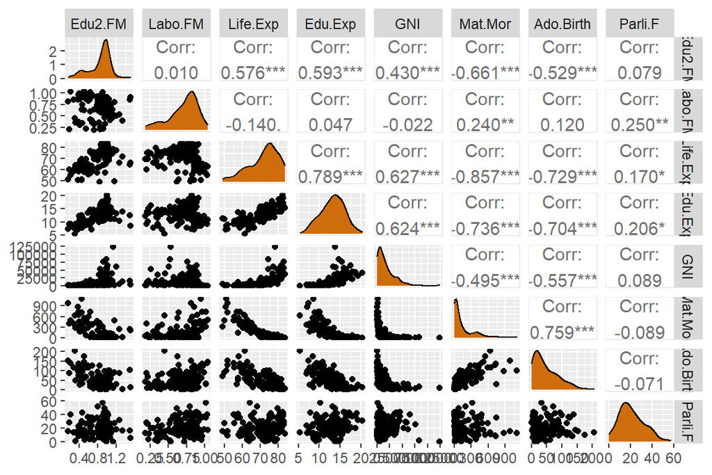

```r
#155 rows and 8 columns as expected

#visualize
library(GGally)
ggpairs(human)
```

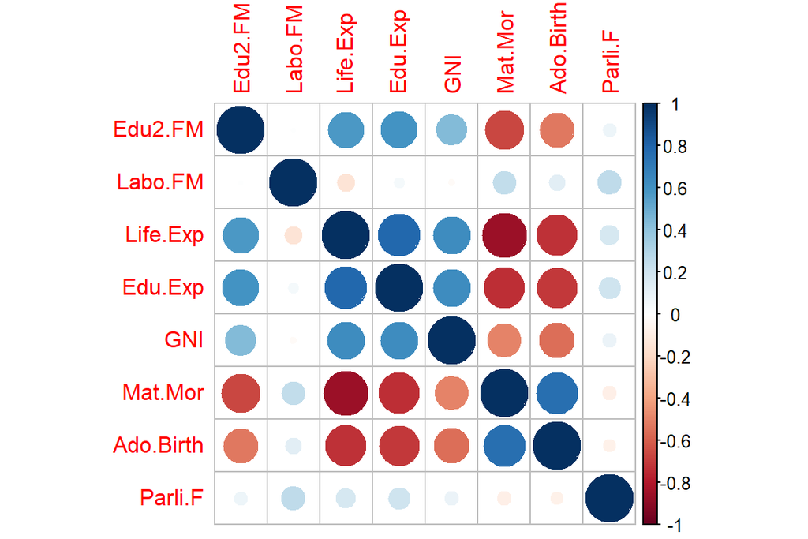

```r
library(corrplot)
cor(human) %>% corrplot()
```

```r
#summary
summary(human)
```

```
##     Edu2.FM          Labo.FM          Life.Exp        Edu.Exp
##  Min.   :0.1717   Min.   :0.1857   Min.   :49.00   Min.   : 5.40
##  1st Qu.:0.7264   1st Qu.:0.5984   1st Qu.:66.30   1st Qu.:11.25
##  Median :0.9375   Median :0.7535   Median :74.20   Median :13.50
##  Mean   :0.8529   Mean   :0.7074   Mean   :71.65   Mean   :13.18
##  3rd Qu.:0.9968   3rd Qu.:0.8535   3rd Qu.:77.25   3rd Qu.:15.20
##  Max.   :1.4967   Max.   :1.0380   Max.   :83.50   Max.   :20.20
##       GNI            Mat.Mor         Ado.Birth         Parli.F
##  Min.   :   581   Min.   :   1.0   Min.   :  0.60   Min.   : 0.00
##  1st Qu.:  4198   1st Qu.:  11.5   1st Qu.: 12.65   1st Qu.:12.40
##  Median : 12040   Median :  49.0   Median : 33.60   Median :19.30
##  Mean   : 17628   Mean   : 149.1   Mean   : 47.16   Mean   :20.91
##  3rd Qu.: 24512   3rd Qu.: 190.0   3rd Qu.: 71.95   3rd Qu.:27.95
##  Max.   :123124   Max.   :1100.0   Max.   :204.80   Max.   :57.50
```

The data to be analyzed combines human welfare and gender equality data sets for countries. Here’s explanations for the variables:

- Life.Exp = life expectancy
- Edu.Exp = expected years of schooling
- GNI = gross national income per capita
- Mat.Mor = maternal mortality ratio
- Ado.Birth = adolescent birth rate
- Parli.F = percentage of female representatives in parliament
- Edu2.FM =ratio of female and male populations with secondary education
- Labo.FM = ratio of female and male populations within the workforce

First, let’s look at obvious skews between mean and median. GNI, maternal mortality ratio and adolescent birth rate all have a higher mean value than median. Thus, although generally for countries the values are low, there’s some countries with very high values which skew the results. This is verified in the pair plot distribution. Life expectancy and proportion of women in parliament are mirrored, where a clear peak is formed at the end or start respectively, but the drop off is gentle towards lower or higher values respectively.  
Adolescent birth rate and maternal mortality ratio have nearly identical correlation profiles, and similarly proportion of women vs men in secondary education, life expectancy, expected years of schooling and GNI have very similar correlation profiles. These two variable groups correlate negatively with each other, which makes sense, as countries with good education and economy generally have better conditions and rights for women. Proportion of women vs men in the labour force or proportion of women in parliament only have weak correlations.

### 2. PCA sans scaling

Next, let’s perform principal component analysis to group the countries.

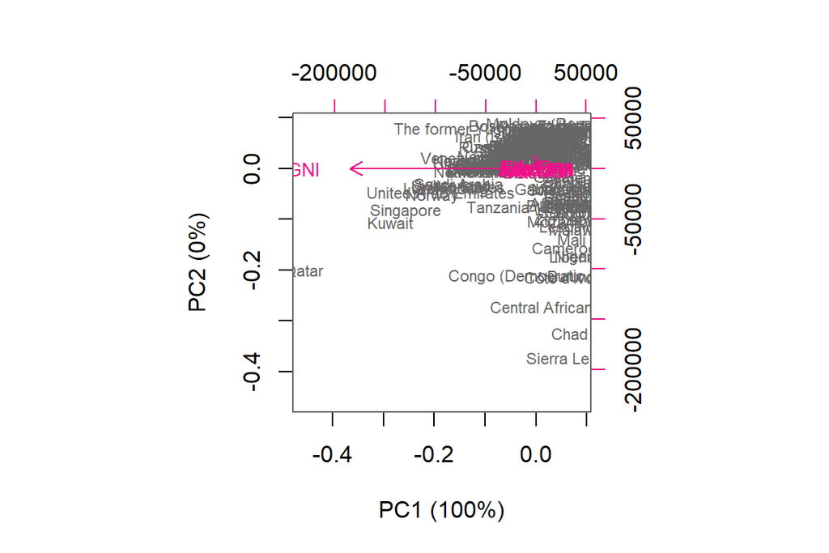

```r
pca <- prcomp(human)
#make the percentages for principal components
s <- summary(pca)
pca_pr <- round(100*s$importance[2, ], digits = 1)
#prep the labels
pc_lab<- paste0(names(pca_pr), " (", pca_pr, "%)")
# draw the pca
biplot(pca, cex = c(0.7, 0.8), col = c("grey40", "deeppink2"), xlab = pc_lab[1], ylab = pc_lab[2])
```

According to the PCA without standardization, and only looking at PC1 as it explains practically all variance, countries would have very similar welfare and gender equality profiles, but high GNI countries like Qatar, Kuwait, Singapore, Norway would have different profiles. If we assume PC2 is maternal mortality ratio then most countries on the positive side of PC2 group together as they have low to average GNI, but due to global medical advances lesser maternal mortality. Then countries with poor GNI and high maternal mortality ratios separate (Sierra Leone, Chad) and countries with very good GNI but also higher than average maternal mortality ratios (Qatar especially, Kuwait, Singapore).

### 3. PCA with scaling

Let’s try scaling the variables first and then creating the plot

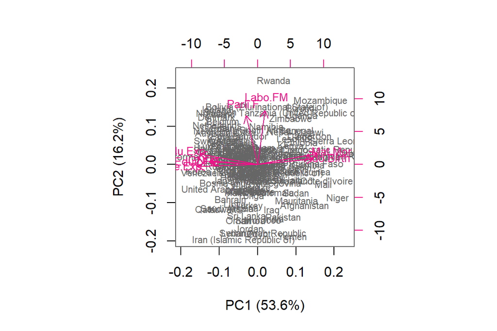

```r
#standardize
human_std <- scale(human)

#pca 2
pca_std <- prcomp(human_std)
#make the percentages for principal components
s_std <- summary(pca_std)
pca_pr_std <- round(100*s_std$importance[2, ], digits = 1)
#prep the labels
pc_lab_std<- paste0(names(pca_pr_std), " (", pca_pr_std, "%)")
# draw the pca
biplot(pca_std, cex = c(0.7, 0.8), col = c("grey40", "deeppink2"), xlab = pc_lab_std[1], ylab = pc_lab_std[2])
```

After scaling the data, a more rational PCA plot is made, where PC1 explains 53 % of variance and PC2 16 %. Countries are distributed along PC1 almost equally strongly towards negative values by expected years of education, life expectancy, gross national income and proportion of women vs men in secondary education. Their angles are similar as they all correlate together as noted before. Maternal mortality ratio and adolescent birth rate go hand in hand, and they pull countries to the positive values on PC1. PC2 on the other hand is described by proportion of women vs men in workforce and proportion of women in parliament, which are relatively closely correlated. This allows a more nuanced look at gender equality in countries without it being skewed by generally better healthcare.  
Clearly standardization is essential for PCA, as GNI with its very high numeric values (max: 123124) completely overtakes the whole unscaled PCA plot. With rounding the principal component 1 explained 100 % of variation. Still, the plot did create a nice pattern, but its impossible to say what contributed to it, probably the second numerically highest variable which was maternal mortality ratio. As this is highly correlated with GNI, the plot is almost one dimensional. Scaling led to a very different plot, which was able to separate countries by variables with smaller numeric values.

### 4. PCA interpretation of standardized data

PC1 essentially describes the economic situation in countries, as a healthier economy leads to better healthcare and thus allows women to have better conditions and for them to also participate in the educational system. PC2 on the other hand gives a better look on the cultural position of women in these countries. Let’s look at the four quadrants separately.  
When PC1 and PC2 are positive the economic situation is poor, but women have, at least relatively, a lot of power in both the workforce and politically. Taking the clear outlier Rwanda as an example, although it ranks averagely on PC1, it seems to rank highest in terms of gender equality. Indeed this is confirmed by the first paragraph in the wikipedia article on the gender equality in Rwanda (https://en.wikipedia.org/wiki/Gender_equality_in_Rwanda).  
When PC1 is positive and PC2 is negative both the economic conditions and women’s rights are poor. As countries with active conflicts, such as Yemen and Afghanistan are highlighted here this makes sense.  
When PC1 and PC2 are negative the economic situation is good but women’s rights are poor. Qatar is a good example of a country with a very high GNI due to a small number of ultra rich individuals, but as it is an Islamic state women don’t have a lot of power.  
When PC1 is negative and PC2 is positive western countries are separated, with northern European countries furthest from the pack. Here economy and women’s rights are in a relatively good position.  
### 5. MCA Finally, we will look at something completely different.

```r
#read data
tea <- read.table("https://raw.githubusercontent.com/KimmoVehkalahti/Helsinki-Open-Data-Science/master/datasets/tea.csv",
                       sep = ",", header = T)
#View(tea)

#remove age, as it is numerical
tea <- dplyr::select(tea,-19)
#glimpse(tea)
#convert all categorical variables to factors with a method given in this thread:
#https://stackoverflow.com/questions/20637360/convert-all-data-frame-character-columns-to-factors
tea <- tea %>% mutate_if(is.character,as.factor)
dim(tea)
```

```
## [1] 300  35
```

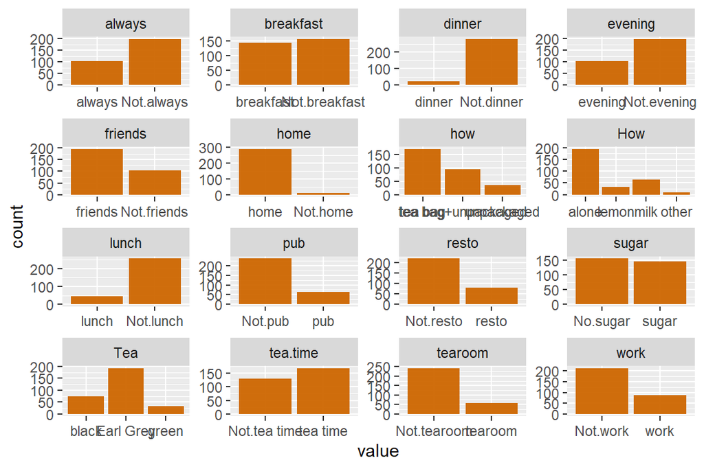

```r
#lets visualize the first 16 variables
library(ggplot2)
pivot_longer(tea[1:16], cols = everything()) %>%
  ggplot(aes(value)) + facet_wrap("name", scales = "free") + geom_bar()
```

```r
library(FactoMineR)
#perform MCA
mca <- MCA(tea[15:21], graph = FALSE)
#get summary
summary(mca)
```

```
##
## Call:
## MCA(X = tea[15:21], graph = FALSE)
##
##
## Eigenvalues
##                        Dim.1   Dim.2   Dim.3   Dim.4   Dim.5   Dim.6   Dim.7
## Variance               0.312   0.244   0.213   0.170   0.168   0.157   0.154
## % of var.             12.119   9.485   8.291   6.600   6.541   6.108   6.008
## Cumulative % of var.  12.119  21.604  29.895  36.496  43.036  49.144  55.152
##                        Dim.8   Dim.9  Dim.10  Dim.11  Dim.12  Dim.13  Dim.14
## Variance               0.142   0.137   0.134   0.128   0.123   0.111   0.106
## % of var.              5.534   5.340   5.228   4.961   4.794   4.301   4.109
## Cumulative % of var.  60.686  66.026  71.254  76.214  81.008  85.309  89.418
##                       Dim.15  Dim.16  Dim.17  Dim.18
## Variance               0.083   0.073   0.068   0.047
## % of var.              3.240   2.851   2.663   1.828
## Cumulative % of var.  92.658  95.509  98.172 100.000
##
## Individuals (the 10 first)
##                         Dim.1    ctr   cos2    Dim.2    ctr   cos2    Dim.3
## 1                    | -0.175  0.033  0.006 |  0.826  0.932  0.136 |  0.853
## 2                    | -0.080  0.007  0.004 | -0.076  0.008  0.003 | -0.031
## 3                    | -0.274  0.080  0.027 | -0.083  0.009  0.002 |  0.000
## 4                    | -0.387  0.160  0.102 |  0.179  0.044  0.022 |  0.281
## 5                    | -0.251  0.067  0.043 |  0.011  0.000  0.000 |  0.238
## 6                    | -0.464  0.230  0.072 |  0.372  0.189  0.046 |  0.594
## 7                    |  0.041  0.002  0.001 | -0.064  0.006  0.002 |  0.635
## 8                    | -0.080  0.007  0.004 | -0.076  0.008  0.003 | -0.031
## 9                    |  0.910  0.885  0.285 | -0.611  0.509  0.128 |  0.623
## 10                   |  0.863  0.796  0.246 | -0.597  0.487  0.118 |  0.260
##                         ctr   cos2
## 1                     1.138  0.145 |
## 2                     0.002  0.001 |
## 3                     0.000  0.000 |
## 4                     0.124  0.054 |
## 5                     0.088  0.039 |
## 6                     0.551  0.118 |
## 7                     0.631  0.207 |
## 8                     0.002  0.001 |
```

[output cut: 21 more lines]

```
## chain store            0.139   6.440 |   0.029   0.036   0.001   0.667 |
## chain store+tea shop   0.475 -11.920 |   0.057   0.056   0.001   0.580 |
## tea shop               0.170   7.123 |  -0.332   0.740   0.012  -1.915 |
## p_branded              0.039   3.432 |  -0.450   4.300   0.094  -5.299 |
## p_cheap                0.011   1.800 |  -0.569   0.506   0.008  -1.520 |
##
## Categorical variables (eta2)
##                        Dim.1 Dim.2 Dim.3
## sugar                | 0.028 0.078 0.121 |
## how                  | 0.579 0.554 0.071 |
## where                | 0.711 0.554 0.012 |
## price                | 0.590 0.304 0.217 |
## sex                  | 0.052 0.134 0.271 |
## SPC                  | 0.214 0.083 0.469 |
## Sport                | 0.008 0.001 0.330 |
```

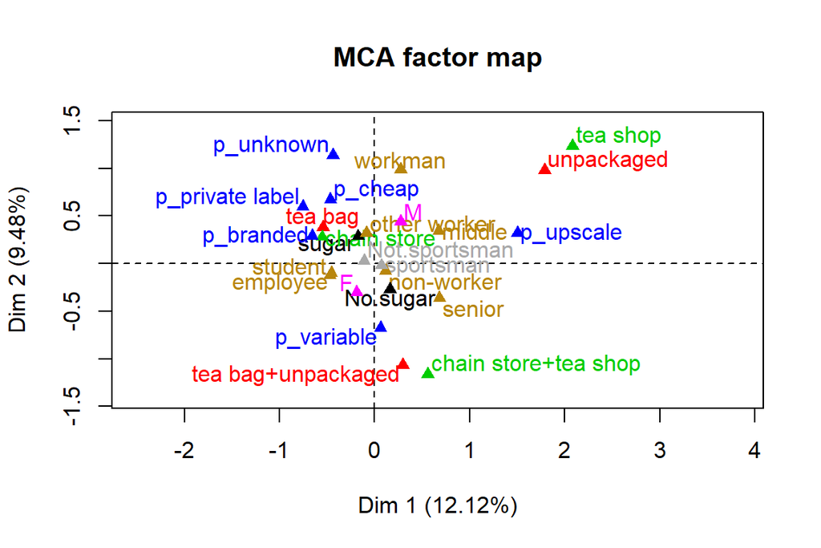

```r
#plot
plot(mca,invisible=c("ind"), graph.type = "classic",habillage="quali")
```

With this random sample of variables, dimensions 1 and 2 explain 22 % of the variance, not too bad! Based on the v.tests in the summary, we can see that e.g. the categories tea bag, unpackaged, chain store and tea shop had significant contributions to the first dimension. Then based on eta2 we can see that variables where, price and how had the most weight for both dimensions.  
Looking at the plot we can see some interesting groupings. For example, when tea is enjoyed in a tea shop it is often unpackaged and it is often upscale, whereas when tea is enjoyed in a chain store, it is often in a tea bag and it is either cheap, branded, private labelled or unknown. Additionally, this kind of tea is enjoyed with sugar. Workmen seem to be closest associated with cheap tea, whereas middle management is closest to upscale tea.

# Analysis of longitudinal data

*Describe the work you have done this week and summarize your learning.*

- Describe your work and results clearly.
- Assume the reader has an introductory course level understanding of writing and reading R code as well as statistical methods.
- Assume the reader has no previous knowledge of your data or the more advanced methods you are using.

```r
date()
```

```
## [1] "Sat Dec 10 21:34:03 2022"
```

### 1. Longitudinal data analysis with an assumption of independence between measurements

In the first part of this report we will investigate data which lists rat weight as a function of time under different nutritional plans.

#### 1.1. Data loading and early investigation

First let’s load in the data and explore it.

```r
library(dplyr)
library(tidyr)
library(ggplot2)

#read data
RATSL <- read.csv("data/ratsl.csv")

#check data was read correctly
glimpse(RATSL)
```

```
## Rows: 176
## Columns: 5
## $ ID     <int> 1, 2, 3, 4, 5, 6, 7, 8, 9, 10, 11, 12, 13, 14, 15, 16, 1, 2, 3,…
## $ Group  <int> 1, 1, 1, 1, 1, 1, 1, 1, 2, 2, 2, 2, 3, 3, 3, 3, 1, 1, 1, 1, 1, …
## $ WD     <chr> "WD1", "WD1", "WD1", "WD1", "WD1", "WD1", "WD1", "WD1", "WD1", …
## $ Weight <int> 240, 225, 245, 260, 255, 260, 275, 245, 410, 405, 445, 555, 470…
## $ Time   <int> 1, 1, 1, 1, 1, 1, 1, 1, 1, 1, 1, 1, 1, 1, 1, 1, 8, 8, 8, 8, 8, …
```

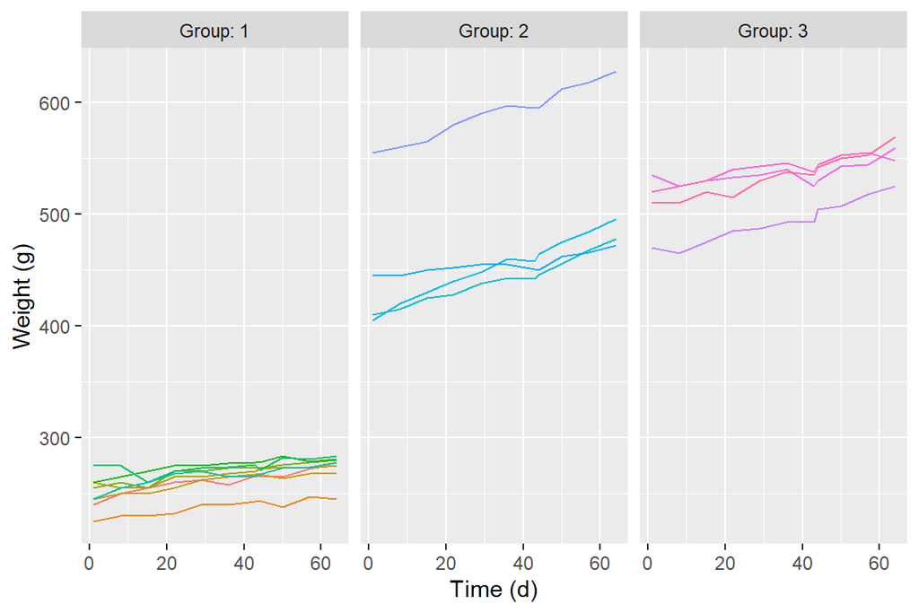

```r
#refactorize ID and Group
RATSL$ID <- factor(RATSL$ID)
RATSL$Group <- factor(RATSL$Group)

#standardize the data and add as column
RATSL <- RATSL %>%
  group_by(Time) %>%
  mutate(stdweight = (Weight - mean(Weight))/sd(Weight)) %>%
  ungroup()

#plot raw data
ggplot(RATSL, aes(x = Time, y = Weight,colour=ID )) +
  geom_line() +
  facet_grid(. ~ Group, labeller = label_both) +
  theme(legend.position = "none") +
  xlab("Time (d)") + ylab("Weight (g)")
```

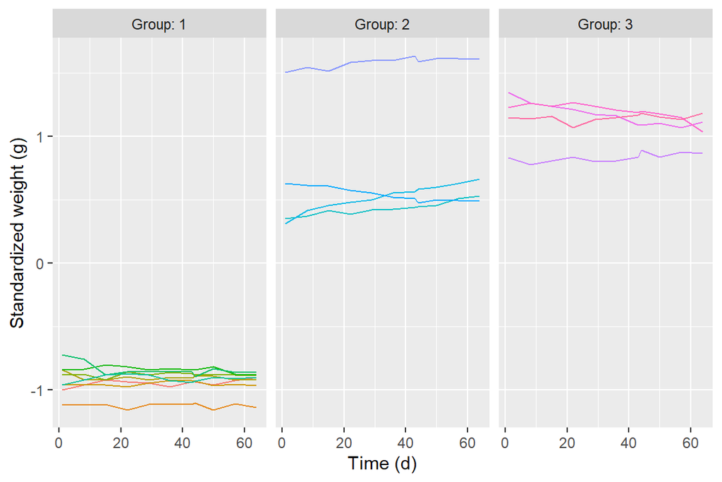

```r
#plot standardized data
ggplot(RATSL, aes(x = Time, y = stdweight,colour=ID ))+
  geom_line() +
  facet_grid(. ~ Group, labeller = label_both) +
  theme(legend.position = "none") +
  xlab("Time (d)") + ylab("Standardized weight (g)")
```

```r
#add standard error as column, but dont divide by sqrt sample size yet because sample sizes vary
RATSS <- RATSL %>%
  group_by(Group, Time) %>%
  summarise( mean = mean(Weight), se = sd(Weight)) %>%
  ungroup()
```

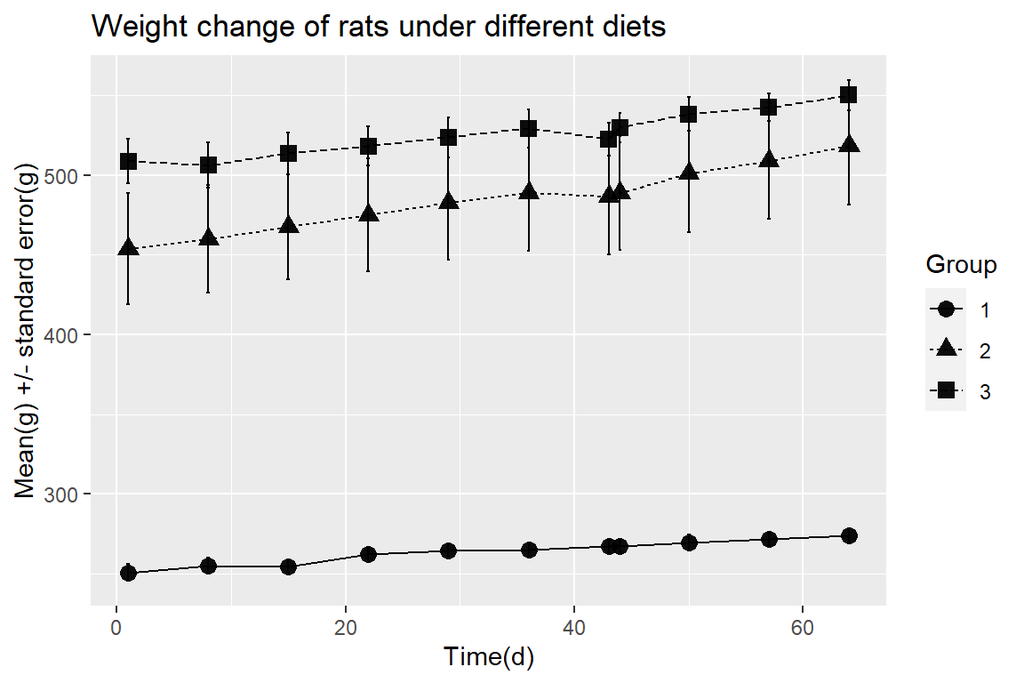

```r
#go over each row
for(i in 1:nrow(RATSS))
{
  #if belongs to group 1
  if (RATSS[i,1] == 1)
  {
    #divide by sqrt 8, where 8 is the number of rats in group 1
    RATSS[i,4] <- RATSS[i,4] / sqrt(8)
  }
  else
  {
    #otherwise divide by sqrt 4 which is the number of rats in groups 2 and 3
    RATSS[i,4] <- RATSS[i,4] / sqrt(4)
  }
}


#plot summary graph
ggplot(RATSS, aes(x = Time, y = mean, linetype = Group, shape = Group)) +
  geom_line() +
  geom_point(size=3) +
  geom_errorbar(aes(ymin=mean-se, ymax=mean+se, linetype="1"), width=0.3) +
  theme(legend.position = c(0.8,0.8)) +
  xlab("Time(d)") +
  ylab("Mean(g) +/- standard error(g)") +
  ggtitle("Weight change of rats under different diets") +
  theme(legend.position = "right")
```

We are interested in seeing whether different diets induced different weight change profiles on rats. Evaluating the first graph by eye gives the impression that group 2 had the most weight gain, then group 3 and lastly group 1. The standardized graph shows well how groups 2 and 3 had significantly higher starting weights, which also stayed high.  
The summary graph tells the same story. Additionally the error bars show how the standard error is the highest in group 2, probably due to the one rat with a very high starting weight. However, in general it is hard to see if there is a difference so let’s change strategies.

#### 1.2. Box plots

Based on previous graphs the weight change is quite stable, i.e. it doesn’t fluctuate remarkably. Thus, as a naive approach we will make box plots on the weight change between days 1 and 64 on an absolute and relative scale. This will naturally ignore all the other day’s data but as there aren’t remarkable fluctuations it should give us a good idea on the cumulation.

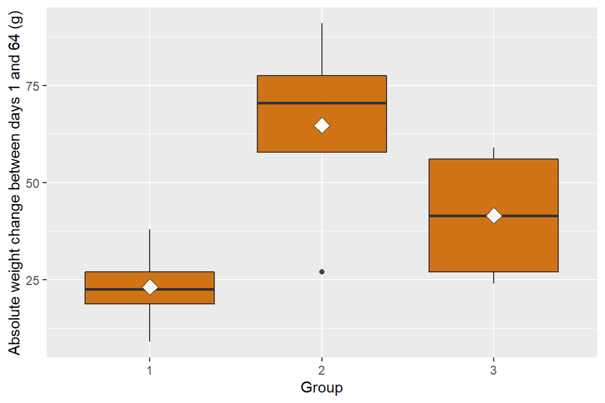

```r
#as done in exercises, assuming day 1 is baseline, creating a summary for days 8-64, but simply plotting this would lead to a comparison between starting weights, which isn't very useful.
#RATSLS <- RATSL %>%
#  filter(Time > 2) %>%
#  group_by(Group, ID) %>%
#  summarise( mean=mean(Weight) ) %>%
#  ungroup()

#calculate relative and absolute change between days 1 and 64
baseline <- filter(RATSL,Time==1)
endpoint <- filter(RATSL,Time==64)
endpoint <- endpoint %>%
  mutate(delta_abs = Weight-baseline$Weight) %>%
  mutate(delta_rel = Weight/baseline$Weight)

#boxplot of absolute weight change
ggplot(endpoint, aes(x = Group, y = delta_abs)) +
  geom_boxplot() +
  stat_summary(fun = "mean", geom = "point", shape=23, size=4, fill = "white") +
  scale_y_continuous(name = "Absolute weight change between days 1 and 64 (g)")
```

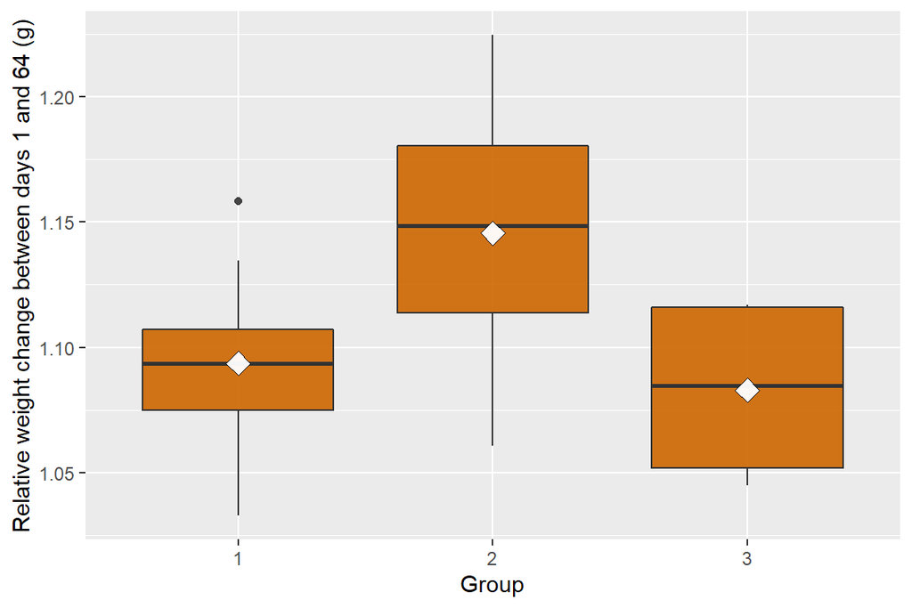

```r
#boxplot of relative weight change
ggplot(endpoint, aes(x = Group, y = delta_rel)) +
  geom_boxplot() +
  stat_summary(fun = "mean", geom = "point", shape=23, size=4, fill = "white") +
  scale_y_continuous(name = "Relative weight change between days 1 and 64 (g)")
```

Based on absolute weight change my previous assessment that most weight gain happens in group 2, then 3, then 1 is correct. Groups 2 and 3 also have more variance. However, relative weight change paints a different picture, where groups 1 and 3 are equal, and 2 barely higher (a difference of ~5 %-units). Like before, groups 2 and 3 have slightly more variance than group 1. In both plots there is one outlier (from different groups), but with such a small sample size it seems unwise to remove them. Especially since the plots of previous graphs were reasonable. This outlier causes slight skewing in the distribution in the absolute scale for group 2.

#### 1.3. Anova

Finally, as we have 3 samples (and thus a two-sample t-test is unsuitable), we’ll perform anova. This time let’s represent weight gain as the mean from days 8-64. For fun, let’s also do it for day 1 vs day 64.

```r
RATSLS <- RATSL %>%
  filter(Time > 1) %>%
  group_by(Group, ID) %>%
  summarise( mean=mean(Weight) ) %>%
  ungroup()
#add baseline back
RATSLS1 <- RATSLS %>%
  mutate(baseline = baseline$Weight)

#fit linear model for anova
fit <- lm(mean ~ baseline + Group, data = RATSLS1)
#compute anova
anova(fit)
```

```
## Analysis of Variance Table
##
## Response: mean
##           Df Sum Sq Mean Sq   F value   Pr(>F)
## baseline   1 253625  253625 1859.8201 1.57e-14 ***
## Group      2    879     439    3.2219  0.07586 .
## Residuals 12   1636     136
## ---
## Signif. codes:  0 '***' 0.001 '**' 0.01 '*' 0.05 '.' 0.1 ' ' 1
```

```r
#day 1 vs 64 comparison for fun
endpoint <- endpoint %>%
  mutate(baseline = baseline$Weight)
fit2 <- lm(Weight ~ baseline + Group, data = endpoint)
anova(fit2)
```

```
## Analysis of Variance Table
##
## Response: Weight
##           Df Sum Sq Mean Sq  F value    Pr(>F)
## baseline   1 285981  285981 961.2875 7.966e-13 ***
## Group      2   2620    1310   4.4042   0.03678 *
## Residuals 12   3570     297
## ---
## Signif. codes:  0 '***' 0.001 '**' 0.01 '*' 0.05 '.' 0.1 ' ' 1
```

Anova tells us that, as expected, the baseline is very significant for explaining variance between the means, but the treatment group isn’t (p=0.076). Thus, at least with this sample size we would have to say that there isn’t a difference between the distributions in groups, i.e. the diets didn’t have differences on weight gain outcomes.  
By only comparing day 1 and day 64, then the group does become significant (p=0.037). Of course, this kind of p-hacking leaves a bad taste in my mouth. However, as I argued in the box plot interpretations, the weight accumulation was very stable between weeks, and thus only looking at the furthest end points is somewhat justified (more prone to errors as well). Naturally this result only tells us that one of the treatment groups is significantly different from the rest, but without proper post-hoc tests (which should have been planned before hand) we can’t know which group is the significantly different one, although group 2 is the likely candidate.  
A more robust way to measure this change would be to take the days 1-32 data average and compare it to 32-64 average, as now using day 1 vs average is dependent on day 1 fluctuations, and day 1 vs day 64 is dependent on both of their fluctuations.

### 2. Longitudinal data analysis with an assumption of dependence between measurements

In this second part we will investigate data of 40 subjects divided to two groups of 20, who are given either treatment 1 or 2 for schizophrenia. The degree of mental health problems are measured with Brief Psychiatric Rating Scale. A higher value means more symptoms.

#### 2.1. Data loading and early investigation

Let’s load in the data and explore it.

```r
#read data
BPRSL <- read.csv("data/bprsl.csv")

#check data was read correctly
glimpse(BPRSL)
```

```
## Rows: 360
## Columns: 5
## $ treatment <int> 1, 1, 1, 1, 1, 1, 1, 1, 1, 1, 1, 1, 1, 1, 1, 1, 1, 1, 1, 1, …
## $ subject   <int> 1, 2, 3, 4, 5, 6, 7, 8, 9, 10, 11, 12, 13, 14, 15, 16, 17, 1…
## $ weeks     <chr> "week0", "week0", "week0", "week0", "week0", "week0", "week0…
## $ bprs      <int> 42, 58, 54, 55, 72, 48, 71, 30, 41, 57, 30, 55, 36, 38, 66, …
## $ week      <int> 0, 0, 0, 0, 0, 0, 0, 0, 0, 0, 0, 0, 0, 0, 0, 0, 0, 0, 0, 0, …
```

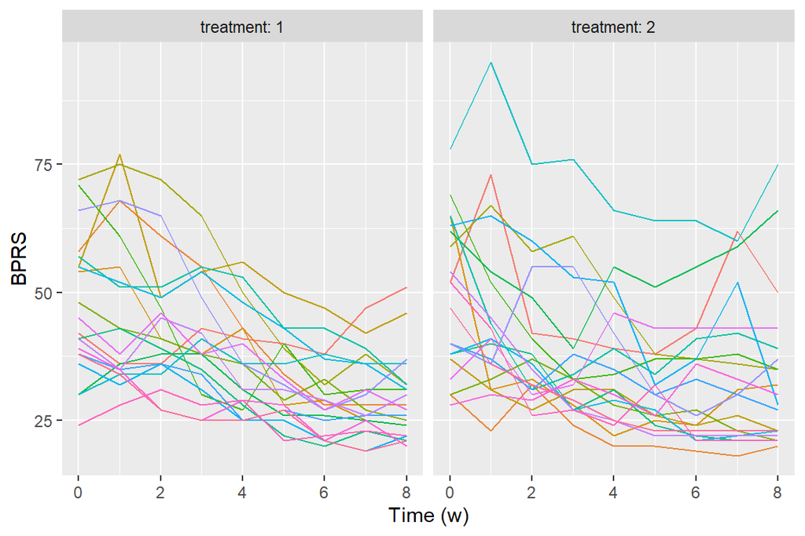

```r
#refactorize
BPRSL$subject <- factor(BPRSL$subject)
BPRSL$treatment <- factor(BPRSL$treatment)

#simple plot
ggplot(BPRSL, aes(x = week, y = bprs, colour = subject)) +
  geom_line()+#aes(linetype = subject)) +
  facet_grid(. ~ treatment, labeller = label_both) +
  theme(legend.position = "none") +
  xlab("Time (w)") + ylab("BPRS")
```

For this data the question is whether one treatment is superior to the other. Based on the development of BPRS over time both treatments seem to work to some extent as BPRS decreases over time in the majority of cases. As in the earlier data set, the tracking phenomenon is visible here as well. For treatment 1 variability seems to decrease over time, but for treatment 2 it stays relatively high.

#### 2.2. Linear regression model

Next we will explore some regression models, starting with a standard linear regression model, which assumes each measurement is independent.

```r
BPRSL_reg <- lm(bprs ~ week + treatment,BPRSL)
summary(BPRSL_reg)
```

```
##
## Call:
## lm(formula = bprs ~ week + treatment, data = BPRSL)
##
## Residuals:
##     Min      1Q  Median      3Q     Max
## -22.454  -8.965  -3.196   7.002  50.244
##
## Coefficients:
##             Estimate Std. Error t value Pr(>|t|)
## (Intercept)  46.4539     1.3670  33.982   <2e-16 ***
## week         -2.2704     0.2524  -8.995   <2e-16 ***
## treatment2    0.5722     1.3034   0.439    0.661
## ---
## Signif. codes:  0 '***' 0.001 '**' 0.01 '*' 0.05 '.' 0.1 ' ' 1
##
## Residual standard error: 12.37 on 357 degrees of freedom
## Multiple R-squared:  0.1851, Adjusted R-squared:  0.1806
## F-statistic: 40.55 on 2 and 357 DF,  p-value: < 2.2e-16
```

Compared to treatment 1, only time (week) has statistically significant correlation (p<2e-16) with BPRS-score. R-squared values tell us that the time dependence explains 20 % of variation.

#### 2.3. Random intercept model

Let’s try to better the model by enabling random intercepts.

```r
library(lme4)
library(lmerTest) # this package gives p-tests for lme4
BPRSL_ref <- lmer(bprs ~ week + treatment + (1 | subject), data = BPRSL, REML = FALSE)
summary(BPRSL_ref)
```

```
## Linear mixed model fit by maximum likelihood . t-tests use Satterthwaite's
##   method [lmerModLmerTest]
## Formula: bprs ~ week + treatment + (1 | subject)
##    Data: BPRSL
##
##      AIC      BIC   logLik deviance df.resid
##   2748.7   2768.1  -1369.4   2738.7      355
##
## Scaled residuals:
##     Min      1Q  Median      3Q     Max
## -3.0481 -0.6749 -0.1361  0.4813  3.4855
##
## Random effects:
##  Groups   Name        Variance Std.Dev.
##  subject  (Intercept)  47.41    6.885
##  Residual             104.21   10.208
## Number of obs: 360, groups:  subject, 20
##
## Fixed effects:
##             Estimate Std. Error       df t value Pr(>|t|)
## (Intercept)  46.4539     1.9090  37.2392  24.334   <2e-16 ***
## week         -2.2704     0.2084 340.0000 -10.896   <2e-16 ***
## treatment2    0.5722     1.0761 340.0000   0.532    0.595
## ---
## Signif. codes:  0 '***' 0.001 '**' 0.01 '*' 0.05 '.' 0.1 ' ' 1
##
## Correlation of Fixed Effects:
##            (Intr) week
## week       -0.437
## treatment2 -0.282  0.000
```

The standard error for treatment 2 slightly decreased, but not remarkably. Overall the significance of week and treatment2 are very similar.

#### 2.4. Random intercept and slope model

Let’s make the slope random as well.

```r
BPRSL_ref1 <- lmer(bprs ~ week + treatment + (week | subject), data = BPRSL, REML = FALSE)
summary(BPRSL_ref1)
```

```
## Linear mixed model fit by maximum likelihood . t-tests use Satterthwaite's
##   method [lmerModLmerTest]
## Formula: bprs ~ week + treatment + (week | subject)
##    Data: BPRSL
##
##      AIC      BIC   logLik deviance df.resid
##   2745.4   2772.6  -1365.7   2731.4      353
##
## Scaled residuals:
##     Min      1Q  Median      3Q     Max
## -2.8919 -0.6194 -0.0691  0.5531  3.7976
##
## Random effects:
##  Groups   Name        Variance Std.Dev. Corr
##  subject  (Intercept) 64.8222  8.0512
##           week         0.9609  0.9802   -0.51
##  Residual             97.4305  9.8707
## Number of obs: 360, groups:  subject, 20
##
## Fixed effects:
##             Estimate Std. Error       df t value Pr(>|t|)
## (Intercept)  46.4539     2.1052  22.6795  22.066  < 2e-16 ***
## week         -2.2704     0.2977  19.9991  -7.626 2.42e-07 ***
## treatment2    0.5722     1.0405 320.0005   0.550    0.583
## ---
## Signif. codes:  0 '***' 0.001 '**' 0.01 '*' 0.05 '.' 0.1 ' ' 1
##
## Correlation of Fixed Effects:
##            (Intr) week
## week       -0.582
## treatment2 -0.247  0.000
```

```r
#compare them with anova
anova(BPRSL_ref1, BPRSL_ref)
```

```
## Data: BPRSL
## Models:
## BPRSL_ref: bprs ~ week + treatment + (1 | subject)
## BPRSL_ref1: bprs ~ week + treatment + (week | subject)
##            npar    AIC    BIC  logLik deviance  Chisq Df Pr(>Chisq)
## BPRSL_ref     5 2748.7 2768.1 -1369.4   2738.7
## BPRSL_ref1    7 2745.4 2772.6 -1365.7   2731.4 7.2721  2    0.02636 *
## ---
## Signif. codes:  0 '***' 0.001 '**' 0.01 '*' 0.05 '.' 0.1 ' ' 1
```

Treatment standard error keeps decreasing. Now week has a random effect correlation of -0.51 and the fixed effect correlation increased further to -0.582. The anova test between models indicated statistically significant difference between them.

#### 2.4. Interacting random intercept and slope model

Finally, let’s allow interaction between week and treatment.

```r
BPRSL_ref2 <-lmer(bprs ~ week * treatment + (week | subject), data = BPRSL, REML = FALSE)
summary(BPRSL_ref2)
```

```
## Linear mixed model fit by maximum likelihood . t-tests use Satterthwaite's
##   method [lmerModLmerTest]
## Formula: bprs ~ week * treatment + (week | subject)
##    Data: BPRSL
##
##      AIC      BIC   logLik deviance df.resid
##   2744.3   2775.4  -1364.1   2728.3      352
##
## Scaled residuals:
##     Min      1Q  Median      3Q     Max
## -3.0512 -0.6271 -0.0768  0.5288  3.9260
##
## Random effects:
##  Groups   Name        Variance Std.Dev. Corr
##  subject  (Intercept) 64.9964  8.0620
##           week         0.9687  0.9842   -0.51
##  Residual             96.4707  9.8220
## Number of obs: 360, groups:  subject, 20
##
## Fixed effects:
##                 Estimate Std. Error       df t value Pr(>|t|)
## (Intercept)      47.8856     2.2521  29.6312  21.262  < 2e-16 ***
## week             -2.6283     0.3589  41.7201  -7.323 5.24e-09 ***
## treatment2       -2.2911     1.9090 319.9977  -1.200   0.2310
## week:treatment2   0.7158     0.4010 319.9977   1.785   0.0752 .
## ---
## Signif. codes:  0 '***' 0.001 '**' 0.01 '*' 0.05 '.' 0.1 ' ' 1
##
## Correlation of Fixed Effects:
##             (Intr) week   trtmn2
## week        -0.650
## treatment2  -0.424  0.469
## wek:trtmnt2  0.356 -0.559 -0.840
```

```r
#compare interacting and non-interacting with anova
anova(BPRSL_ref2, BPRSL_ref1)
```

```
## Data: BPRSL
## Models:
## BPRSL_ref1: bprs ~ week + treatment + (week | subject)
## BPRSL_ref2: bprs ~ week * treatment + (week | subject)
##            npar    AIC    BIC  logLik deviance  Chisq Df Pr(>Chisq)
## BPRSL_ref1    7 2745.4 2772.6 -1365.7   2731.4
## BPRSL_ref2    8 2744.3 2775.4 -1364.1   2728.3 3.1712  1    0.07495 .
## ---
## Signif. codes:  0 '***' 0.001 '**' 0.01 '*' 0.05 '.' 0.1 ' ' 1
```

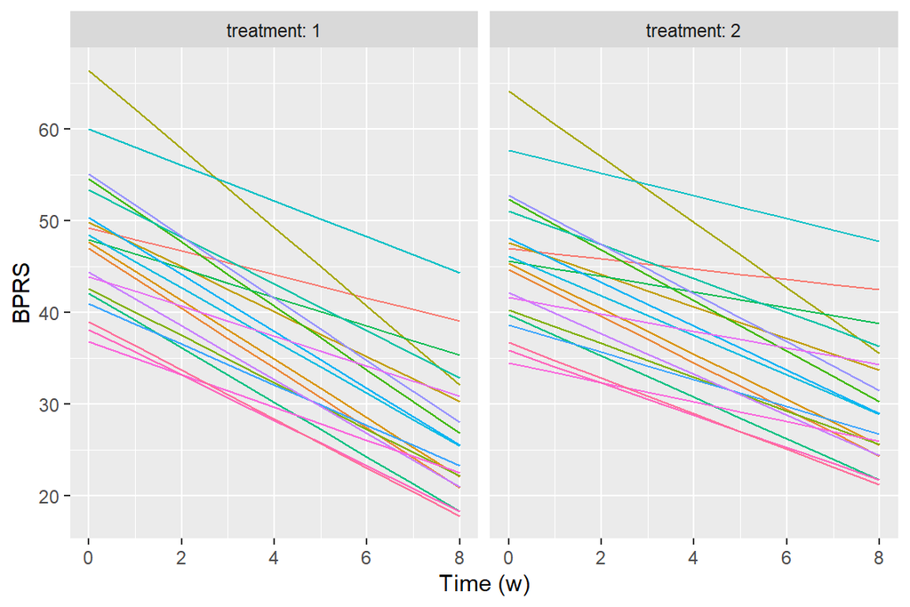

```r
#add fitted values as a column
Fitted <- fitted(BPRSL_ref2)
BPRSL <- mutate(BPRSL,fitted=Fitted)

#draw fitted values
ggplot(BPRSL, aes(x = week, y = fitted, colour = subject)) +
  geom_line()+#aes(linetype = subject)) +
  facet_grid(. ~ treatment, labeller = label_both) +
  theme(legend.position = "none") +
  xlab("Time (w)") + ylab("BPRS")
```

```r
#confidence interval
confint(BPRSL_ref2)
```

```
## Computing profile confidence intervals ...
```

```
##                       2.5 %     97.5 %
## .sig01           5.39069597 12.1613571
## .sig02          -0.82694500  0.1404228
## .sig03           0.43747319  1.6543265
## .sigma           9.10743668 10.6349246
## (Intercept)     43.31885100 52.4522602
## week            -3.34923718 -1.9074295
## treatment2      -6.04400897  1.4617868
## week:treatment2 -0.07243289  1.5040996
```

Overall the model parameters between an interacting and non-interacting model remain very similar. In fact, the combined ANOVA test between them revealed that they were not statistically significantly different.  
Regardless, based on the coefficient of treatment2 and its standard error, it is impossible to say whether it is better or worse than treatment 1. I.e. we don’t know if compared to treatment 1 it decreases or increases BPRS-score. This result matches with the confidence interval which spans 0.